# Analysis - Excluding Amendments

> Quid pro quo? An explanation for why partisan alignment pays off

# Data

The unit of analysis in our dataset is the pair municipality $i$ ministry $j$ observerd in year $t$. In total, this structure comprises `740112` observations, with `5565` unique municipalities and `17` unique ministries.

## Proposals

In our sample, municipalities requested on average `508219.18` Brazilian reais (adjusted for inflation) between 2009 and 2016, or `37.16` reais per capita. There is a total of `422010` proposals that were submited by municipalities to the Federal Government requesting transfers. Finally, of all municipality-ministry-year units, `597264` did not submit any proposals, `80.7%` of all units.

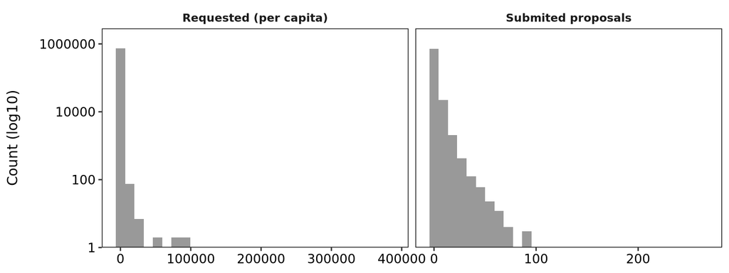

## Ministries

The plot below the distribution of submited proposals by ministries they targeted.

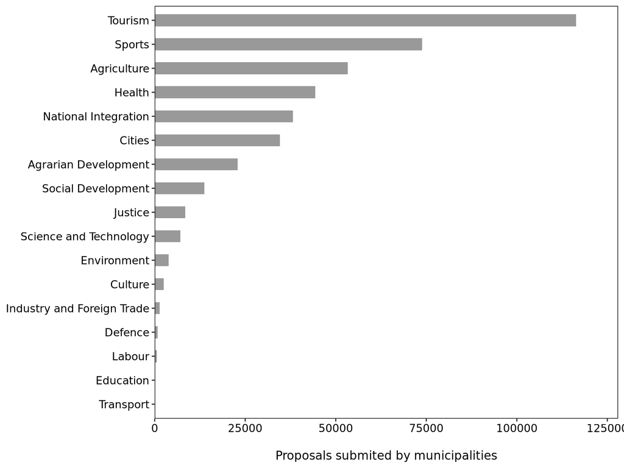

# Partisan Aligment

## Difference in means

### Considering non-responders as zero

Below we estimate differences in distributive outcomes between aligned and non-aligned municipality-ministry pairs. In particular, for values we do not observe in variables such as `Proportion of rejected proposals` (i.e., we only observe rejection status for municipalities that submited proposals) we input the value of zero. In this way, we deal with attrition by assuming non-submission as an inferior type of submission.

|  | Non-aligned (N=655444) Mean | Non-aligned (N=655444) Std. Dev. | Aligned (N=81336) Mean | Aligned (N=81336) Std. Dev. | Diff. in Means | Std. Error |
| --- | --- | --- | --- | --- | --- | --- |
| Submited proposals | 0.54 | 1.94 | 0.80 | 2.38 | 0.26 | 0.01 |
| Empenhado per capita | 1.22 | 13.29 | 2.50 | 18.16 | 1.28 | 0.07 |
| N convenios | 0.05 | 0.31 | 0.10 | 0.45 | 0.05 | 0.00 |
| Prop. rejected proposals | 0.03 | 0.14 | 0.03 | 0.15 | 0.00 | 0.00 |
| Avg. attachments | 0.70 | 2.96 | 1.15 | 3.72 | 0.45 | 0.01 |
| Avg. object word count | 3.45 | 16.06 | 4.64 | 18.12 | 1.19 | 0.07 |
| Avg. justification word count | 52.88 | 136.47 | 79.34 | 167.61 | 26.46 | 0.61 |
| Prop. ata posse | 0.25 | 1.93 | 0.36 | 2.14 | 0.11 | 0.01 |
| Prop. plano de trabalho | 0.22 | 1.74 | 0.36 | 2.06 | 0.14 | 0.01 |
| Prop. cotações | 0.17 | 1.58 | 0.27 | 1.86 | 0.10 | 0.01 |
| Prop. cronograma | 0.05 | 0.86 | 0.07 | 0.91 | 0.02 | 0.00 |
| Avg. payments to providers | 0.21 | 4.12 | 0.41 | 5.26 | 0.20 | 0.02 |
| Avg. number of providers | 0.06 | 0.83 | 0.12 | 1.02 | 0.06 | 0.00 |
| Avg. providers’ time in operation | 0.40 | 2.76 | 0.82 | 4.08 | 0.42 | 0.01 |
| Avg. diárias payments | 0.00 | 0.00 | 0.00 | 0.00 | 0.00 | 0.00 |
| Provider donnor (dummy) | 0.00 | 0.02 | 0.00 | 0.03 | 0.00 | 0.00 |

### Subsample

In this part, we reestimate the difference in means using a sub-sample of our data that contains a smaller proportion of non-observed outcomes. To that end, we subseted ou sample to include only the following ministries: “National Integration”, “Health”, “Cities”, “Agriculture”, “Tourism”, “Sports”. In addition, we filtered out municipalities with fewer than 30k inhabitants. After these procedures, our resulting sample have `50028` observations, with `27412` that did not submit any proposals, `54.8%`.

|  | Non-aligned (N=43051) Mean | Non-aligned (N=43051) Std. Dev. | Aligned (N=6839) Mean | Aligned (N=6839) Std. Dev. | Diff. in Means | Std. Error |
| --- | --- | --- | --- | --- | --- | --- |
| Submited proposals | 1.72 | 3.89 | 2.00 | 4.51 | 0.28 | 0.06 |
| Empenhado per capita | 1.23 | 9.51 | 1.86 | 9.28 | 0.62 | 0.12 |
| N convenios | 0.20 | 0.64 | 0.26 | 0.79 | 0.07 | 0.01 |
| Prop. rejected proposals | 0.04 | 0.17 | 0.04 | 0.16 | -0.00 | 0.00 |
| Avg. attachments | 2.00 | 4.70 | 2.43 | 5.12 | 0.43 | 0.07 |
| Avg. object word count | 8.55 | 22.41 | 8.73 | 22.38 | 0.18 | 0.29 |
| Avg. justification word count | 129.10 | 188.44 | 147.35 | 205.36 | 18.25 | 2.64 |
| Prop. ata posse | 0.79 | 3.46 | 0.84 | 3.16 | 0.05 | 0.04 |
| Prop. plano de trabalho | 0.55 | 2.71 | 0.62 | 2.62 | 0.07 | 0.03 |
| Prop. cotações | 0.43 | 2.54 | 0.45 | 2.25 | 0.02 | 0.03 |
| Prop. cronograma | 0.15 | 1.45 | 0.11 | 1.01 | -0.04 | 0.01 |
| Avg. payments to providers | 0.70 | 4.61 | 0.96 | 5.89 | 0.26 | 0.07 |
| Avg. number of providers | 0.16 | 0.78 | 0.23 | 0.94 | 0.07 | 0.01 |
| Avg. providers’ time in operation | 1.36 | 5.15 | 1.96 | 6.29 | 0.60 | 0.08 |
| Avg. diárias payments | 0.00 | 0.00 | 0.00 | 0.00 | 0.00 | 0.00 |
| Provider donnor (dummy) | 0.00 | 0.06 | 0.00 | 0.06 | 0.00 | 0.00 |

## Difference-in-Differences

### Main variables

|  | Empenhado per capita (DiD) | Empenhado per capita (DDD) | Submited proposals (DiD) | Submited proposals (DDD) |
| --- | --- | --- | --- | --- |
| Partisan aligment | 0.50*** | 0.54*** | 0.08*** | 0.11*** |
|  | (0.12) | (0.12) | (0.01) | (0.02) |
| Num.Obs. | 736780 | 736780 | 736780 | 736780 |
| Std.Errors | by: cod_ibge | by: cod_ibge | by: cod_ibge | by: cod_ibge |

### Quality of proposals

|  | Partisan aligment |
| --- | --- |
| Prop. rejected proposals (DiD) | 0.00 [0.00, 0.00]* |
| Prop. rejected proposals (DDD) | 0.00 [0.00, 0.00]* |
| Avg. attachments (DiD) | 0.13 [0.08, 0.17]*** |
| Avg. attachments (DDD) | 0.12 [0.07, 0.17]*** |
| Avg. object word count (DiD) | 0.14 [−0.08, 0.36] |
| Avg. object word count (DDD) | 0.23 [−0.01, 0.47]+ |
| Avg. just. word count (DiD) | 2.34 [0.74, 3.94]** |
| Avg. just. word count (DDD) | 3.99 [2.27, 5.71]*** |
| Prop. ata posse (DiD) | 0.04 [0.01, 0.07]** |
| Prop. ata posse (DDD) | 0.03 [0.01, 0.06]* |
| Prop. plano de trabalho (DiD) | 0.02 [0.00, 0.04] |
| Prop. plano de trabalho (DDD) | 0.01 [−0.01, 0.04] |
| Prop. cotações (DiD) | 0.03 [0.01, 0.05]** |
| Prop. cotações (DDD) | 0.02 [0.00, 0.04]+ |
| Prop. cronograma (DiD) | 0.02 [0.00, 0.03]** |
| Prop. cronograma (DDD) | 0.02 [0.00, 0.03]* |

### Quality of providers

|  | Partisan aligment |
| --- | --- |
| Avg. payments to providers (DiD) | 0.07 [0.02, 0.12]** |
| Avg. payments to providers (DDD) | 0.09 [0.04, 0.15]*** |
| Avg. number of providers (DiD) | 0.02 [0.01, 0.03]*** |
| Avg. number of providers (DDD) | 0.03 [0.02, 0.04]*** |
| Avg. providers’ time in operation (DiD) | 0.16 [0.11, 0.20]*** |
| Avg. providers’ time in operation (DDD) | 0.19 [0.14, 0.24]*** |
| At least 1 small company (dummy) (DiD) | 0.01 [0.01, 0.01]*** |
| At least 1 small company (dummy) (DDD) | 0.01 [0.01, 0.01]*** |
| Provider donnor (dummy) (DiD) | 0.00 [0.00, 0.00] |
| Provider donnor (dummy) (DDD) | 0.00 [0.00, 0.00] |